# Diabetes 130-US hospitals for years 1999-2008

WILHEM CASTRO

11/29/2020

## Diabetes 130-US hospitals for years 1999-2008

Los datos provienen del Centro de Investigación Clínica y Traslacional de la Virginia Commonwealth University. Reflejan Informacion de pacientes con diabetes en 130 hospitales de EE. UU. Durante un período de diez años desde 1999 hasta 2008. Hay más de 100.000 ingresos hospitalarios únicos en este conjunto de datos, de aproximadamente 70.000 pacientes únicos. Los datos incluyen elementos demográficos, como edad, sexo y raza, así como atributos clínicos como pruebas realizadas, visitas de emergencia

Objetivos - Identificar diferentes insights asociados a los típos de readmisión de los pacientes.

- Propones un modelo de clasificación, que permita predecir el típo de readmisión de los pacientes.

Metodología:

Se realizó una etapa de preparación de datos. Posteriormente se exploraron los datos de manera univariada y multivariada. Acto seguido, se realiza elproceso de feature engineering y se construye el set de entrenamiento y validación. Finalmente, se propone el modelo XGBoost como estrategia de clasificación.

## Carga de Datos

```r
#Data Loading----

ds<- read.csv('diabetic_data.csv')
dim(ds)
```

```
## [1] 101766     50
```

```r
names(ds)
```

```
##  [1] "encounter_id"             "patient_nbr"
##  [3] "race"                     "gender"
##  [5] "age"                      "weight"
##  [7] "admission_type_id"        "discharge_disposition_id"
##  [9] "admission_source_id"      "time_in_hospital"
## [11] "payer_code"               "medical_specialty"
## [13] "num_lab_procedures"       "num_procedures"
## [15] "num_medications"          "number_outpatient"
## [17] "number_emergency"         "number_inpatient"
## [19] "diag_1"                   "diag_2"
## [21] "diag_3"                   "number_diagnoses"
## [23] "max_glu_serum"            "A1Cresult"
## [25] "metformin"                "repaglinide"
## [27] "nateglinide"              "chlorpropamide"
## [29] "glimepiride"              "acetohexamide"
## [31] "glipizide"                "glyburide"
## [33] "tolbutamide"              "pioglitazone"
## [35] "rosiglitazone"            "acarbose"
## [37] "miglitol"                 "troglitazone"
## [39] "tolazamide"               "examide"
## [41] "citoglipton"              "insulin"
## [43] "glyburide.metformin"      "glipizide.metformin"
## [45] "glimepiride.pioglitazone" "metformin.rosiglitazone"
## [47] "metformin.pioglitazone"   "change"
## [49] "diabetesMed"              "readmitted"
```

```r
#head(ds)
dim(ds)
```

```
## [1] 101766     50
```

Se cuenta con 101766 registros y 50 variables

## Datos Faltantes y manipulación de datos

```r
#Data Preparation---
round(sapply(ds, function(x) sum(x=="?"))/101766*100,2)
```

```
##             encounter_id              patient_nbr                     race
##                     0.00                     0.00                     2.23
##                   gender                      age                   weight
##                     0.00                     0.00                    96.86
##        admission_type_id discharge_disposition_id      admission_source_id
##                     0.00                     0.00                     0.00
##         time_in_hospital               payer_code        medical_specialty
##                     0.00                    39.56                    49.08
##       num_lab_procedures           num_procedures          num_medications
##                     0.00                     0.00                     0.00
##        number_outpatient         number_emergency         number_inpatient
##                     0.00                     0.00                     0.00
##                   diag_1                   diag_2                   diag_3
##                     0.02                     0.35                     1.40
##         number_diagnoses            max_glu_serum                A1Cresult
##                     0.00                     0.00                     0.00
##                metformin              repaglinide              nateglinide
##                     0.00                     0.00                     0.00
##           chlorpropamide              glimepiride            acetohexamide
##                     0.00                     0.00                     0.00
##                glipizide                glyburide              tolbutamide
##                     0.00                     0.00                     0.00
##             pioglitazone            rosiglitazone                 acarbose
##                     0.00                     0.00                     0.00
##                 miglitol             troglitazone               tolazamide
##                     0.00                     0.00                     0.00
##                  examide              citoglipton                  insulin
##                     0.00                     0.00                     0.00
##      glyburide.metformin      glipizide.metformin glimepiride.pioglitazone
##                     0.00                     0.00                     0.00
##  metformin.rosiglitazone   metformin.pioglitazone                   change
##                     0.00                     0.00                     0.00
##              diabetesMed               readmitted
##                     0.00                     0.00
```

```r
ds<-ds[,c(-6,-11,-12)]
#str(ds)
dim(ds)
```

```
## [1] 101766     47
```

Como se puede observar existen campos con una alta proporción de datos faltantes, por lo que no se tendrán en cuenta en el análisis.

Estos campos son:

- weight
- payer
- code
- medical specialty

```r
str(ds)
```

```
## 'data.frame':    101766 obs. of  47 variables:
##  $ encounter_id            : int  2278392 149190 64410 500364 16680 35754 55842 63768 12522 15738 ...
##  $ patient_nbr             : int  8222157 55629189 86047875 82442376 42519267 82637451 84259809 114882984 48330783 63555939 ...
##  $ race                    : Factor w/ 6 levels "?","AfricanAmerican",..: 4 4 2 4 4 4 4 4 4 4 ...
##  $ gender                  : Factor w/ 3 levels "Female","Male",..: 1 1 1 2 2 2 2 2 1 1 ...
##  $ age                     : Factor w/ 10 levels "[0-10)","[10-20)",..: 1 2 3 4 5 6 7 8 9 10 ...
##  $ admission_type_id       : int  6 1 1 1 1 2 3 1 2 3 ...
##  $ discharge_disposition_id: int  25 1 1 1 1 1 1 1 1 3 ...
##  $ admission_source_id     : int  1 7 7 7 7 2 2 7 4 4 ...
##  $ time_in_hospital        : int  1 3 2 2 1 3 4 5 13 12 ...
##  $ num_lab_procedures      : int  41 59 11 44 51 31 70 73 68 33 ...
##  $ num_procedures          : int  0 0 5 1 0 6 1 0 2 3 ...
##  $ num_medications         : int  1 18 13 16 8 16 21 12 28 18 ...
##  $ number_outpatient       : int  0 0 2 0 0 0 0 0 0 0 ...
##  $ number_emergency        : int  0 0 0 0 0 0 0 0 0 0 ...
```

[output cut: 33 more lines]

Teniendo en cuenta que algunos campos numéricos no aportan mucha información (por ejemplo el lugar codificado desde que los pacientes fueron dados de alta “discharge_disposition_id”), pero si lo pueden hacer como variables categóricas, se procede a redefinirlos como factores.

```r
#Cambiar algunos numéricos a factor
ds$admission_source_id<- as.factor(ds$admission_source_id)
levels(ds$admission_source_id)
```

```
##  [1] "1"  "2"  "3"  "4"  "5"  "6"  "7"  "8"  "9"  "10" "11" "13" "14" "17" "20"
## [16] "22" "25"
```

```r
ds$admission_type_id<- as.factor(ds$admission_type_id)
levels(ds$admission_type_id)
```

```
## [1] "1" "2" "3" "4" "5" "6" "7" "8"
```

```r
ds$discharge_disposition_id<-as.factor(ds$discharge_disposition_id)
levels(ds$discharge_disposition_id)
```

```
##  [1] "1"  "2"  "3"  "4"  "5"  "6"  "7"  "8"  "9"  "10" "11" "12" "13" "14" "15"
## [16] "16" "17" "18" "19" "20" "22" "23" "24" "25" "27" "28"
```

## Campos Numéricos

A continuación, se muestran los gráficos de densidad y boxplot para estas variables. Posteriormene se realiza una prueba Tukey para explorar la significancia de cada una de ella respecto del tipo de readmisión.

## Tiempo de estadía en el Hospital

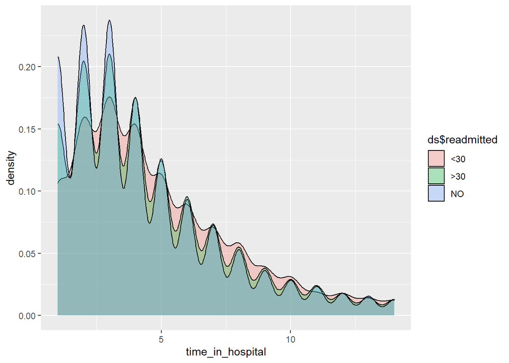

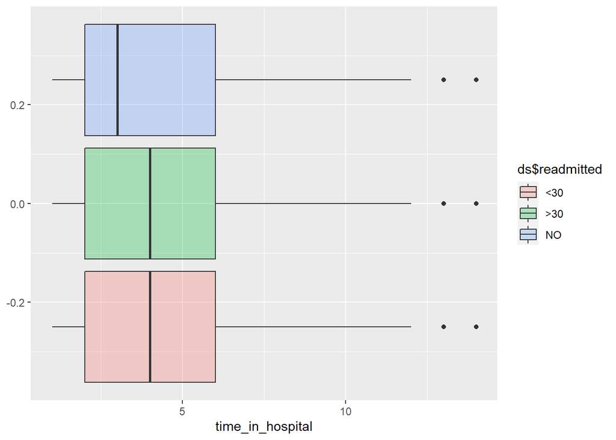

```
##
##  Descriptive statistics by group
## group: <30
##    vars     n mean   sd median trimmed  mad min max range skew kurtosis   se
## X1    1 11357 4.77 3.03      4    4.43 2.97   1  14    13 0.98     0.47 0.03
## ------------------------------------------------------------
## group: >30
##    vars     n mean   sd median trimmed  mad min max range skew kurtosis   se
## X1    1 35545  4.5 2.99      4    4.11 2.97   1  14    13  1.1     0.76 0.02
## ------------------------------------------------------------
## group: NO
##    vars     n mean   sd median trimmed  mad min max range skew kurtosis   se
## X1    1 54864 4.25 2.96      3    3.83 2.97   1  14    13  1.2     1.02 0.01
```

```
##   Tukey multiple comparisons of means
##     95% family-wise confidence level
##
## Fit: aov(formula = num$time_in_hospital ~ ds$readmitted)
##
## $`ds$readmitted`
##               diff        lwr        upr p adj
## >30-<30 -0.2727078 -0.3479940 -0.1974216     0
## NO-<30  -0.5138195 -0.5858246 -0.4418145     0
## NO->30  -0.2411117 -0.2886686 -0.1935548     0
```

# Número de Exámenes de Laboratorio

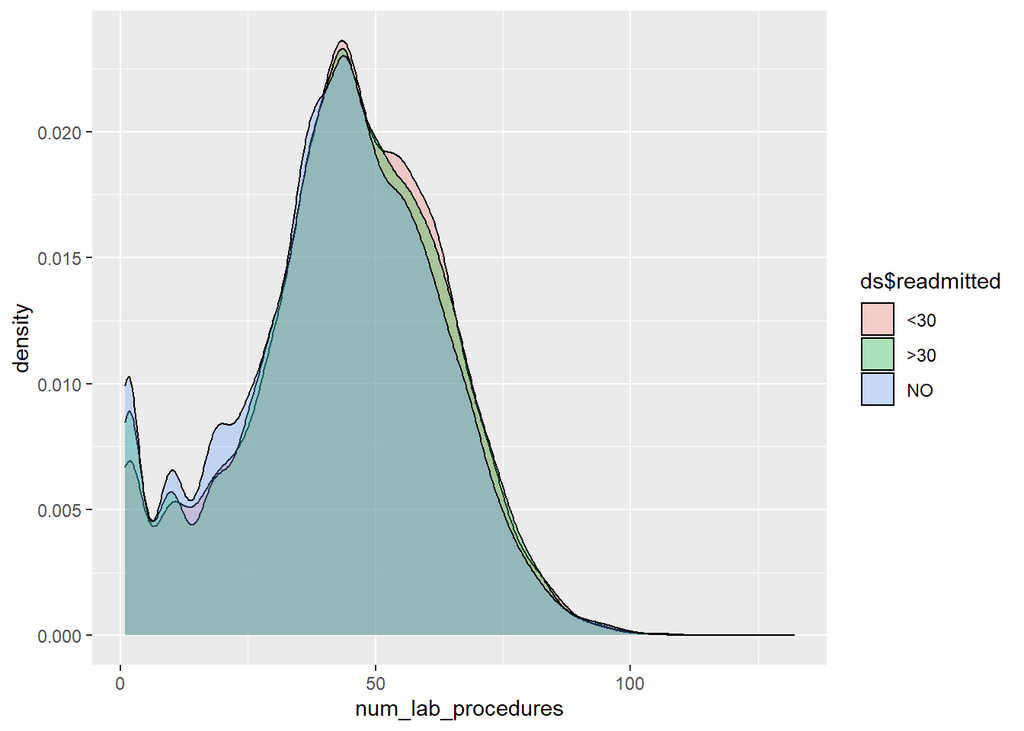

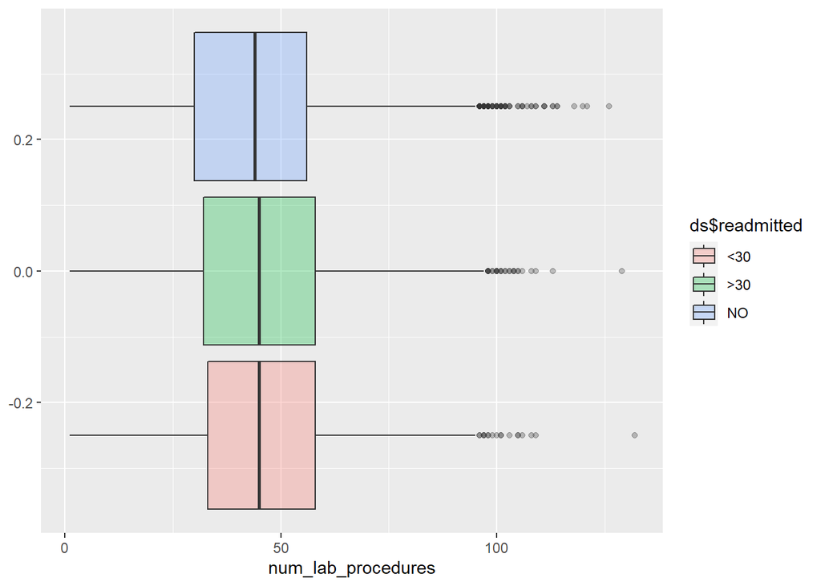

```
##
##  Descriptive statistics by group
## group: <30
##    vars     n  mean    sd median trimmed   mad min max range  skew kurtosis
## X1    1 11357 44.23 19.28     45      45 17.79   1 132   131 -0.28    -0.13
##      se
## X1 0.18
## ------------------------------------------------------------
## group: >30
##    vars     n  mean    sd median trimmed   mad min max range  skew kurtosis  se
## X1    1 35545 43.84 19.57     45   44.64 19.27   1 129   128 -0.29    -0.22 0.1
## ------------------------------------------------------------
## group: NO
##    vars     n  mean   sd median trimmed   mad min max range  skew kurtosis   se
## X1    1 54864 42.38 19.8     44   42.97 19.27   1 126   125 -0.19    -0.27 0.08
```

```
##   Tukey multiple comparisons of means
##     95% family-wise confidence level
##
## Fit: aov(formula = num$num_lab_procedures ~ ds$readmitted)
##
## $`ds$readmitted`
##               diff        lwr        upr     p adj
## >30-<30 -0.3894265 -0.8860641  0.1072111 0.1573457
## NO-<30  -1.8444299 -2.3194230 -1.3694367 0.0000000
## NO->30  -1.4550034 -1.7687202 -1.1412865 0.0000000
```

# Número de Procedimientos

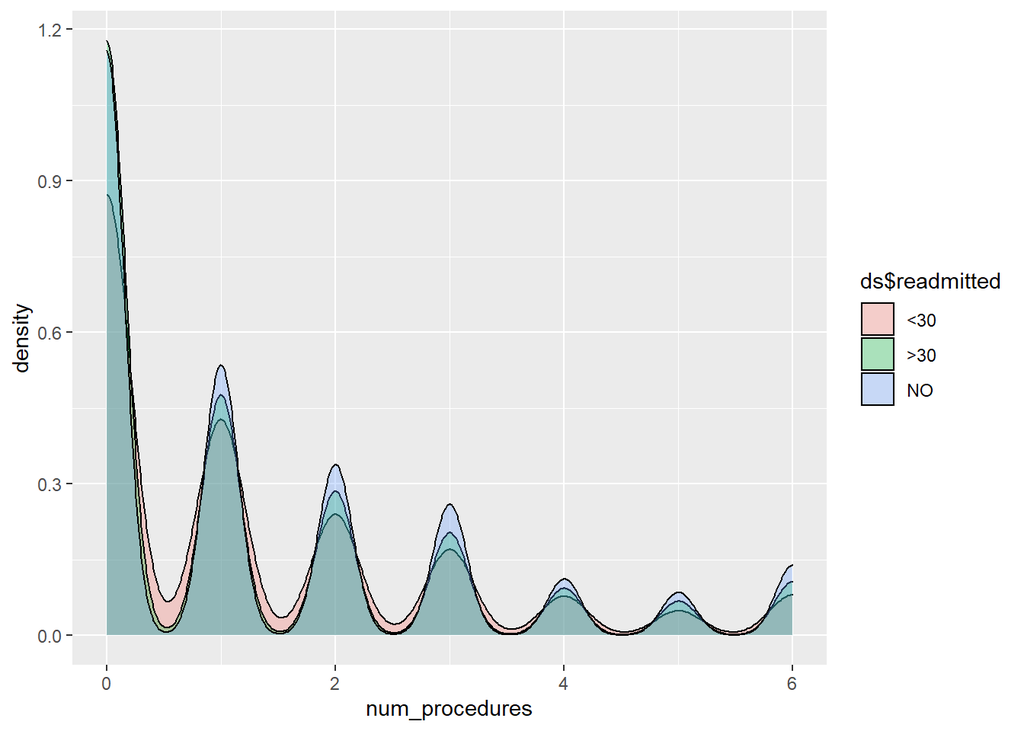

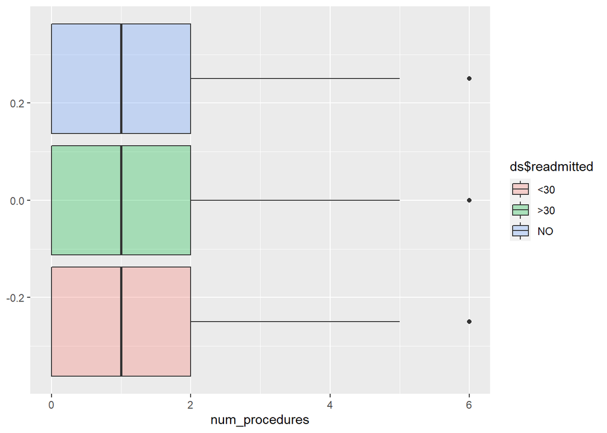

```
##
##  Descriptive statistics by group
## group: <30
##    vars     n mean   sd median trimmed  mad min max range skew kurtosis   se
## X1    1 11357 1.28 1.64      1    0.96 1.48   0   6     6 1.38     1.17 0.02
## ------------------------------------------------------------
## group: >30
##    vars     n mean   sd median trimmed  mad min max range skew kurtosis   se
## X1    1 35545 1.25 1.67      1    0.92 1.48   0   6     6 1.41     1.16 0.01
## ------------------------------------------------------------
## group: NO
##    vars     n mean   sd median trimmed  mad min max range skew kurtosis   se
## X1    1 54864 1.41 1.74      1    1.09 1.48   0   6     6 1.24     0.63 0.01
```

```
##   Tukey multiple comparisons of means
##     95% family-wise confidence level
##
## Fit: aov(formula = num$num_procedures ~ ds$readmitted)
##
## $`ds$readmitted`
##                diff         lwr       upr     p adj
## >30-<30 -0.03128494 -0.07433457 0.0117647 0.2039427
## NO-<30   0.12942145  0.08824800 0.1705949 0.0000000
## NO->30   0.16070638  0.13351272 0.1879000 0.0000000
```

# Número de Medicamentos

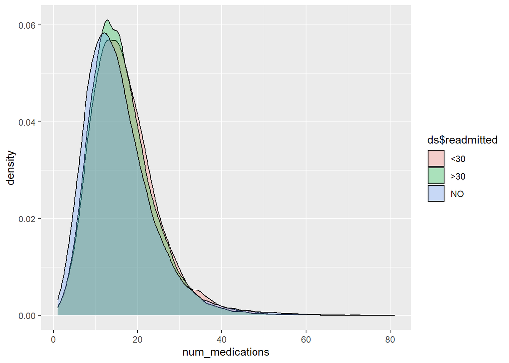

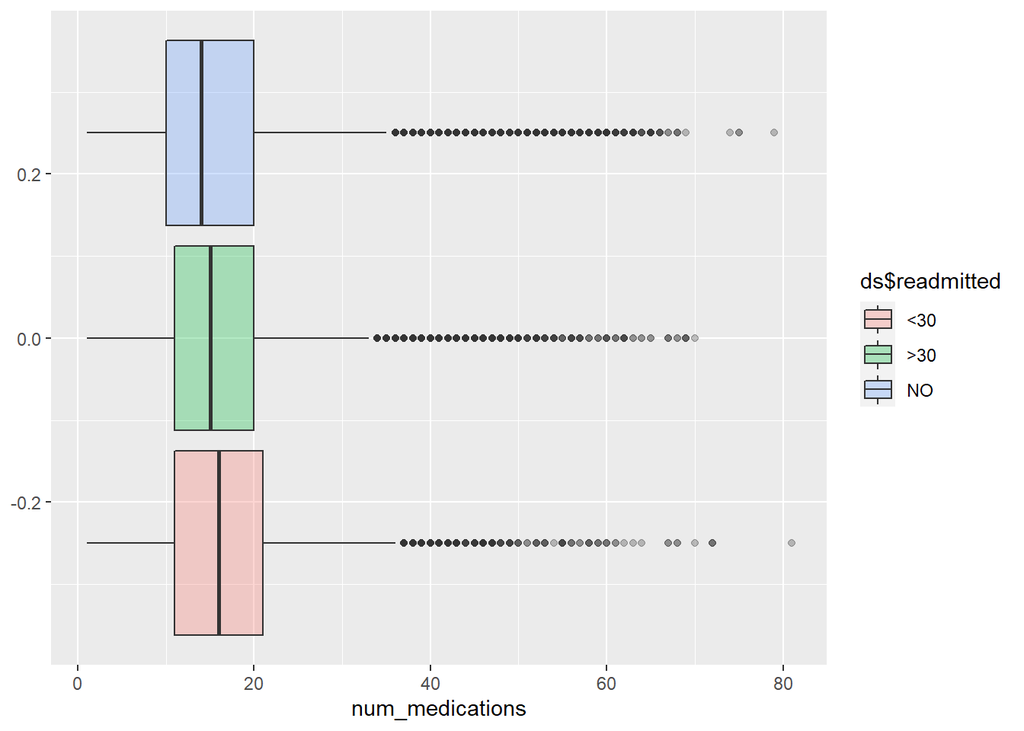

```
##
##  Descriptive statistics by group
## group: <30
##    vars     n mean  sd median trimmed  mad min max range skew kurtosis   se
## X1    1 11357 16.9 8.1     16   16.15 7.41   1  81    80 1.32      3.8 0.08
## ------------------------------------------------------------
## group: >30
##    vars     n  mean   sd median trimmed  mad min max range skew kurtosis   se
## X1    1 35545 16.28 7.62     15   15.63 7.41   1  70    69 1.16     2.92 0.04
## ------------------------------------------------------------
## group: NO
##    vars     n  mean   sd median trimmed  mad min max range skew kurtosis   se
## X1    1 54864 15.67 8.43     14   14.78 7.41   1  79    78 1.42     3.66 0.04
```

```
##   Tukey multiple comparisons of means
##     95% family-wise confidence level
##
## Fit: aov(formula = num$num_medications ~ ds$readmitted)
##
## $`ds$readmitted`
##               diff        lwr        upr p adj
## >30-<30 -0.6203751 -0.8254246 -0.4153256     0
## NO-<30  -1.2327767 -1.4288897 -1.0366637     0
## NO->30  -0.6124016 -0.7419276 -0.4828756     0
```

# Número de Tratamientos Ambulatorios

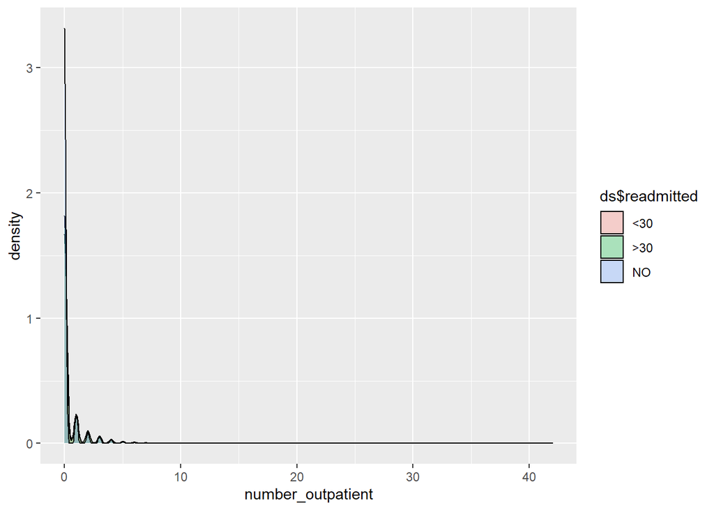

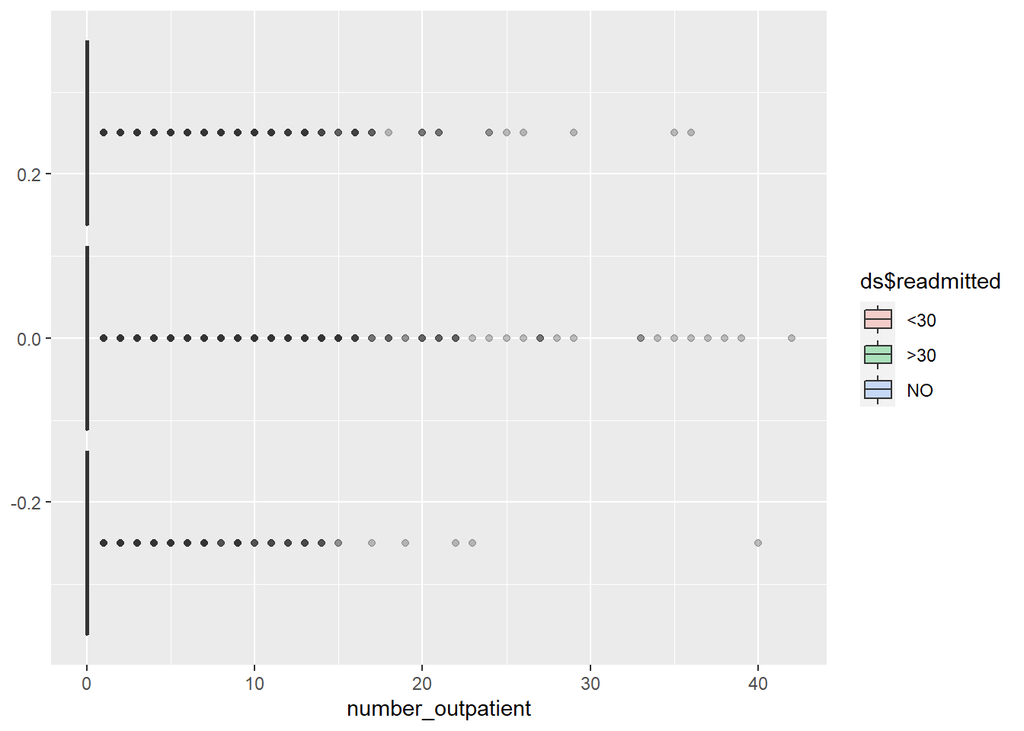

```
##
##  Descriptive statistics by group
## group: <30
##    vars     n mean  sd median trimmed mad min max range skew kurtosis   se
## X1    1 11357 0.44 1.3      0    0.13   0   0  40    40 7.51   118.93 0.01
## ------------------------------------------------------------
## group: >30
##    vars     n mean   sd median trimmed mad min max range skew kurtosis   se
## X1    1 35545  0.5 1.54      0    0.15   0   0  42    42 8.41   126.25 0.01
## ------------------------------------------------------------
## group: NO
##    vars     n mean   sd median trimmed mad min max range skew kurtosis se
## X1    1 54864 0.27 1.03      0    0.03   0   0  36    36 8.67   143.68  0
```

```
##   Tukey multiple comparisons of means
##     95% family-wise confidence level
##
## Fit: aov(formula = num$number_outpatient ~ ds$readmitted)
##
## $`ds$readmitted`
##                diff         lwr        upr    p adj
## >30-<30  0.05941744  0.02751399  0.0913209 3.78e-05
## NO-<30  -0.16379946 -0.19431250 -0.1332864 0.00e+00
## NO->30  -0.22321690 -0.24336973 -0.2030641 0.00e+00
```

# Número de Atenciones de Urgencia

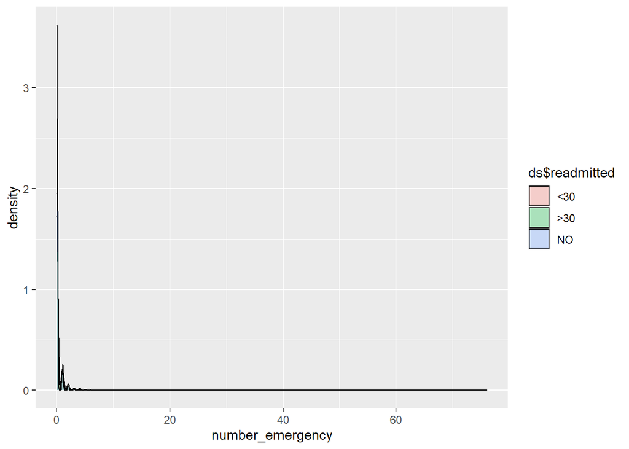

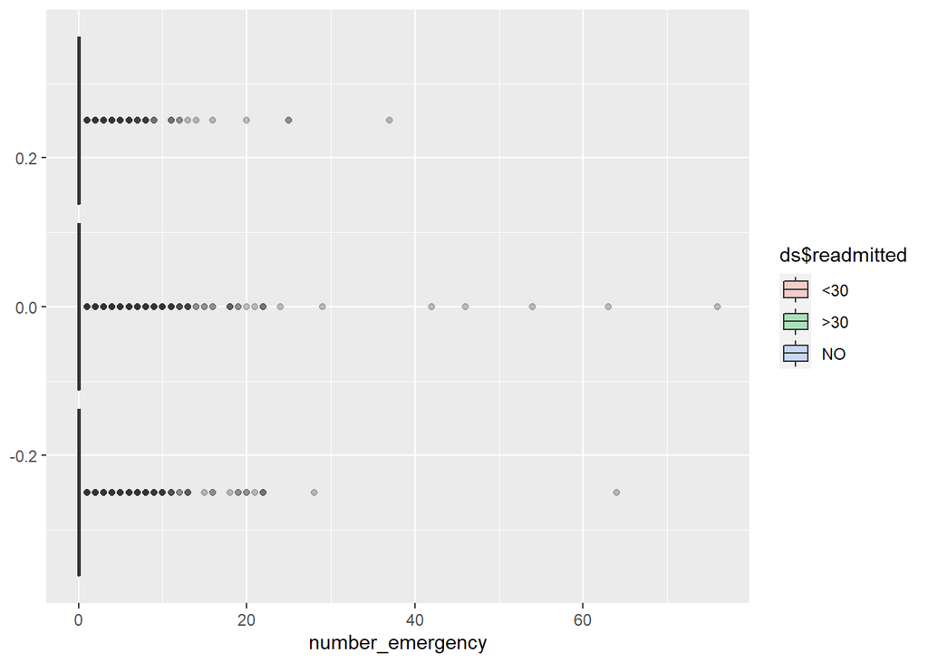

```
##
##  Descriptive statistics by group
## group: <30
##    vars     n mean   sd median trimmed mad min max range  skew kurtosis   se
## X1    1 11357 0.36 1.37      0    0.08   0   0  64    64 14.69   475.65 0.01
## ------------------------------------------------------------
## group: >30
##    vars     n mean   sd median trimmed mad min max range  skew kurtosis   se
## X1    1 35545 0.28 1.19      0    0.06   0   0  76    76 21.23   937.14 0.01
## ------------------------------------------------------------
## group: NO
##    vars     n mean   sd median trimmed mad min max range  skew kurtosis se
## X1    1 54864 0.11 0.52      0       0   0   0  37    37 17.39   757.67  0
```

```
##   Tukey multiple comparisons of means
##     95% family-wise confidence level
##
## Fit: aov(formula = num$number_emergency ~ ds$readmitted)
##
## $`ds$readmitted`
##                diff         lwr         upr p adj
## >30-<30 -0.07364408 -0.09701908 -0.05026908     0
## NO-<30  -0.24809716 -0.27045343 -0.22574089     0
## NO->30  -0.17445307 -0.18921863 -0.15968752     0
```

# Número de Hospitalizaciones

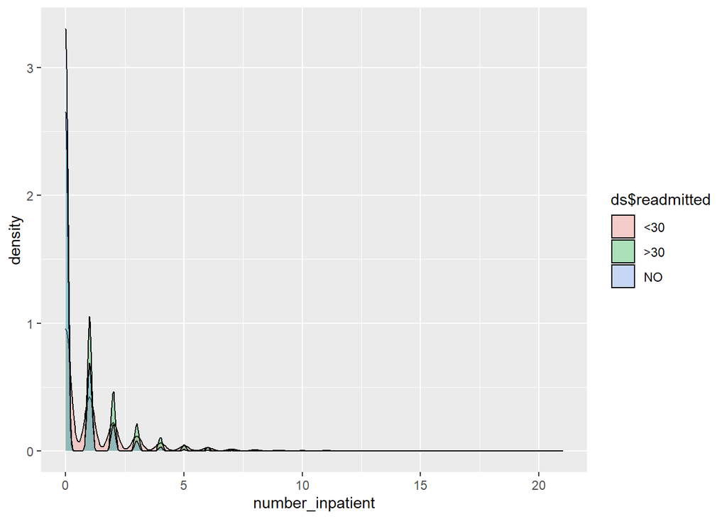

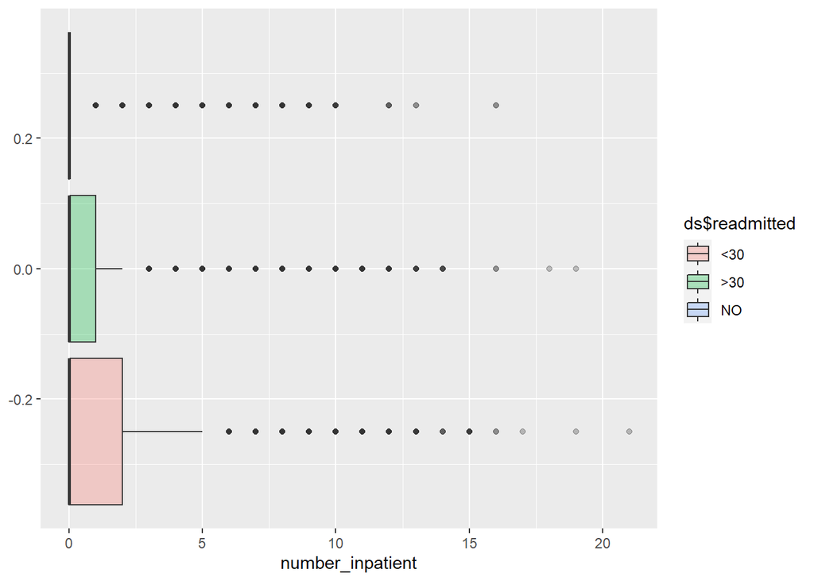

```
##
##  Descriptive statistics by group
## group: <30
##    vars     n mean   sd median trimmed mad min max range skew kurtosis   se
## X1    1 11357 1.22 1.95      0    0.79   0   0  21    21 2.79    10.98 0.02
## ------------------------------------------------------------
## group: >30
##    vars     n mean   sd median trimmed mad min max range skew kurtosis   se
## X1    1 35545 0.84 1.39      0    0.53   0   0  19    19 2.92    13.58 0.01
## ------------------------------------------------------------
## group: NO
##    vars     n mean   sd median trimmed mad min max range skew kurtosis se
## X1    1 54864 0.38 0.86      0    0.18   0   0  16    16 3.78    23.99  0
```

```
##   Tukey multiple comparisons of means
##     95% family-wise confidence level
##
## Fit: aov(formula = num$number_inpatient ~ ds$readmitted)
##
## $`ds$readmitted`
##               diff        lwr        upr p adj
## >30-<30 -0.3850100 -0.4160231 -0.3539969     0
## NO-<30  -0.8420401 -0.8717016 -0.8123787     0
## NO->30  -0.4570302 -0.4766206 -0.4374397     0
```

# Número de Diagnósticos

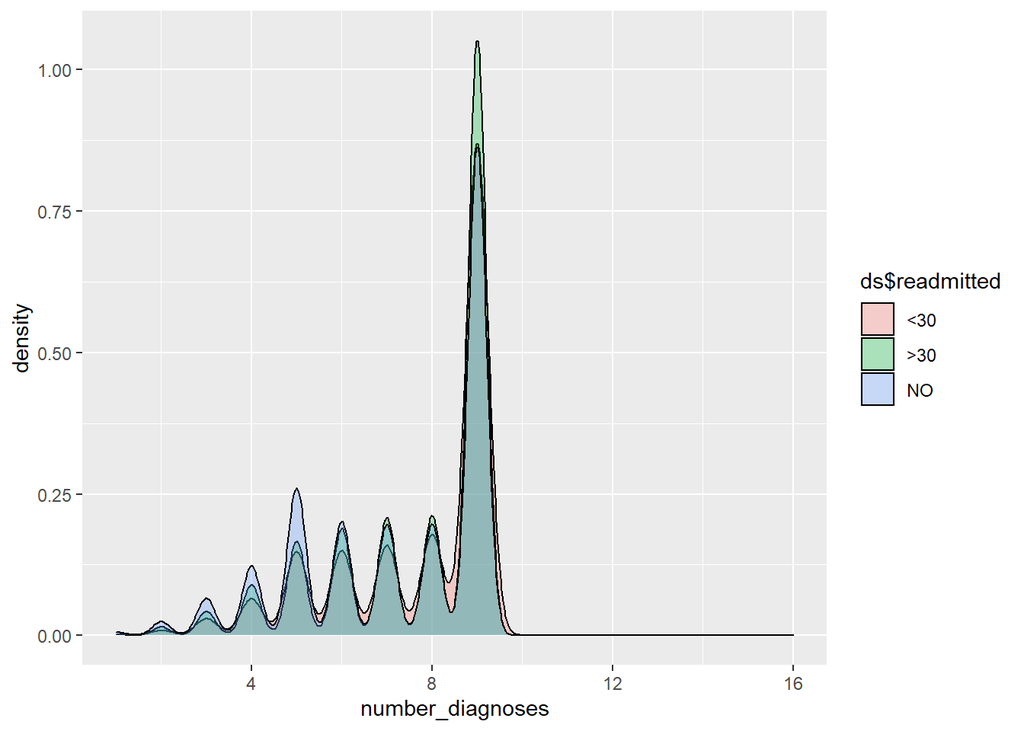

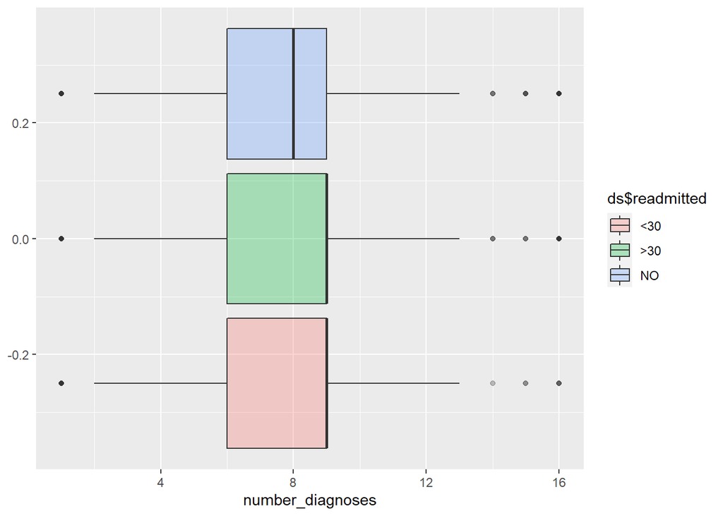

```
##
##  Descriptive statistics by group
## group: <30
##    vars     n mean   sd median trimmed mad min max range  skew kurtosis   se
## X1    1 11357 7.69 1.77      9    7.98   0   1  16    15 -1.08     0.46 0.02
## ------------------------------------------------------------
## group: >30
##    vars     n mean   sd median trimmed mad min max range  skew kurtosis   se
## X1    1 35545 7.65 1.81      9    7.95   0   1  16    15 -1.08     0.44 0.01
## ------------------------------------------------------------
## group: NO
##    vars     n mean   sd median trimmed  mad min max range  skew kurtosis   se
## X1    1 54864 7.22 2.02      8    7.48 1.48   1  16    15 -0.71     -0.4 0.01
```

```
##   Tukey multiple comparisons of means
##     95% family-wise confidence level
##
## Fit: aov(formula = num$number_diagnoses ~ ds$readmitted)
##
## $`ds$readmitted`
##                diff         lwr          upr     p adj
## >30-<30 -0.04589029 -0.09442676  0.002646182 0.0685035
## NO-<30  -0.47142303 -0.51784418 -0.425001877 0.0000000
## NO->30  -0.42553274 -0.45619234 -0.394873143 0.0000000
```

# Asociaciones entre Campos Numéricos

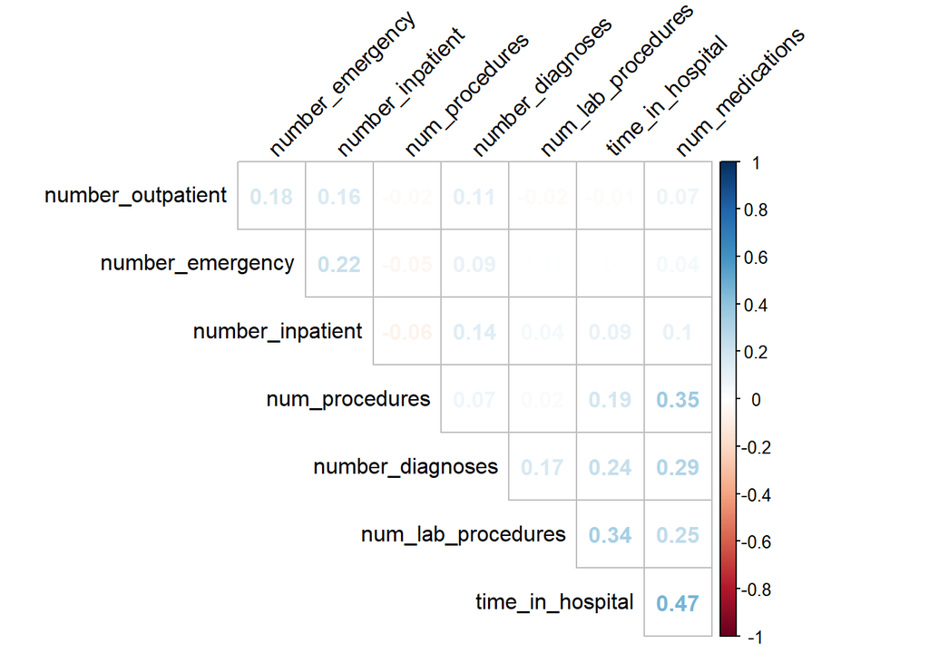

No hay asociaciones muy fuertes entre las variables, con excepción del tiempo de hospitalización y el número de medicamentos, asociación fácilmente comprensible.

Previo al procesamiento de las variables categóricas, se muestra gráficamente el comportamiento de todos los campos numéricos respecto de los tipos de readmisión y se realiza una estandarización de todos ellos.

```
## [1] "<30" ">30" "NO"
```

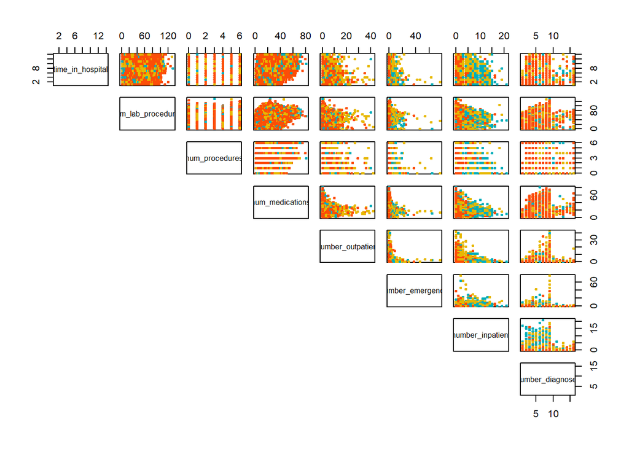

```
##                    vars      n mean sd median trimmed  mad   min   max range
## time_in_hospital      1 101766    0  1  -0.13   -0.13 0.99 -1.14  3.22  4.35
## num_lab_procedures    2 101766    0  1   0.05    0.04 0.98 -2.14  4.52  6.66
## num_procedures        3 101766    0  1  -0.20   -0.19 0.87 -0.79  2.73  3.52
## num_medications       4 101766    0  1  -0.13   -0.10 0.91 -1.85  7.99  9.84
## number_outpatient     5 101766    0  1  -0.29   -0.23 0.00 -0.29 32.85 33.14
## number_emergency      6 101766    0  1  -0.21   -0.20 0.00 -0.21 81.47 81.68
## number_inpatient      7 101766    0  1  -0.50   -0.23 0.00 -0.50 16.13 16.63
## number_diagnoses      8 101766    0  1   0.30    0.15 0.77 -3.32  4.44  7.76
##                     skew kurtosis se
## time_in_hospital    1.13     0.85  0
## num_lab_procedures -0.24    -0.25  0
## num_procedures      1.32     0.86  0
## num_medications     1.33     3.47  0
## number_outpatient   8.83   147.90  0
## number_emergency   22.85  1191.60  0
## number_inpatient    3.61    20.72  0
## number_diagnoses   -0.88    -0.08  0
```

## Variables Categóricas

Ahora, se contruyen las 36 tablas cruzadas correspondiantes a las asociaciones entre todas las variables categóricas y la variable respuesta(“readmittion”). También, se realizan pruebas chi-squared para estimar la significancia entre cada variable categórica y la variable respuesta(“readmitted”). Lo anterior nos ayuda a tener una idea de qué variables aportarían o no en el proceso de clasificación.

A continuación, se muestran las tablas sólo como ejemplo ilustrativo, pues algunos campos de estos tienen muchos niveles(36 tablas).

```r
#Categóricos----
fact_cols <- unlist(lapply(ds, is.factor))         # Categoricos
fact<-ds[,fact_cols]
names(fact)
```

```
##  [1] "race"                     "gender"
##  [3] "age"                      "admission_type_id"
##  [5] "discharge_disposition_id" "admission_source_id"
##  [7] "diag_1"                   "diag_2"
##  [9] "diag_3"                   "max_glu_serum"
## [11] "A1Cresult"                "metformin"
## [13] "repaglinide"              "nateglinide"
## [15] "chlorpropamide"           "glimepiride"
## [17] "acetohexamide"            "glipizide"
## [19] "glyburide"                "tolbutamide"
## [21] "pioglitazone"             "rosiglitazone"
## [23] "acarbose"                 "miglitol"
## [25] "troglitazone"             "tolazamide"
## [27] "examide"                  "citoglipton"
## [29] "insulin"                  "glyburide.metformin"
## [31] "glipizide.metformin"      "glimepiride.pioglitazone"
## [33] "metformin.rosiglitazone"  "metformin.pioglitazone"
## [35] "change"                   "diabetesMed"
## [37] "readmitted"
```

```r
dim(fact)
```

```
## [1] 101766     37
```

```r
prop.table(table(fact$readmitted))# Hay un pequeño desbalance para <30
```

```
##
##       <30       >30        NO
## 0.1115992 0.3492817 0.5391192
```

```r
str(fact)
```

```
## 'data.frame':    101766 obs. of  37 variables:
##  $ race                    : Factor w/ 6 levels "?","AfricanAmerican",..: 4 4 2 4 4 4 4 4 4 4 ...
##  $ gender                  : Factor w/ 3 levels "Female","Male",..: 1 1 1 2 2 2 2 2 1 1 ...
##  $ age                     : Factor w/ 10 levels "[0-10)","[10-20)",..: 1 2 3 4 5 6 7 8 9 10 ...
##  $ admission_type_id       : Factor w/ 8 levels "1","2","3","4",..: 6 1 1 1 1 2 3 1 2 3 ...
##  $ discharge_disposition_id: Factor w/ 26 levels "1","2","3","4",..: 24 1 1 1 1 1 1 1 1 3 ...
##  $ admission_source_id     : Factor w/ 17 levels "1","2","3","4",..: 1 7 7 7 7 2 2 7 4 4 ...
##  $ diag_1                  : Factor w/ 717 levels "?","10","11",..: 126 145 456 556 56 265 265 278 254 284 ...
##  $ diag_2                  : Factor w/ 749 levels "?","11","110",..: 1 81 80 99 26 248 248 316 262 48 ...
##  $ diag_3                  : Factor w/ 790 levels "?","11","110",..: 1 123 768 250 88 88 772 88 231 319 ...
##  $ max_glu_serum           : Factor w/ 4 levels ">200",">300",..: 3 3 3 3 3 3 3 3 3 3 ...
##  $ A1Cresult               : Factor w/ 4 levels ">7",">8","None",..: 3 3 3 3 3 3 3 3 3 3 ...
##  $ metformin               : Factor w/ 4 levels "Down","No","Steady",..: 2 2 2 2 2 2 3 2 2 2 ...
##  $ repaglinide             : Factor w/ 4 levels "Down","No","Steady",..: 2 2 2 2 2 2 2 2 2 2 ...
##  $ nateglinide             : Factor w/ 4 levels "Down","No","Steady",..: 2 2 2 2 2 2 2 2 2 2 ...
```

[output cut: 23 more lines]

```r
names(fact)
```

```
##  [1] "race"                     "gender"
##  [3] "age"                      "admission_type_id"
##  [5] "discharge_disposition_id" "admission_source_id"
##  [7] "diag_1"                   "diag_2"
##  [9] "diag_3"                   "max_glu_serum"
## [11] "A1Cresult"                "metformin"
## [13] "repaglinide"              "nateglinide"
## [15] "chlorpropamide"           "glimepiride"
## [17] "acetohexamide"            "glipizide"
## [19] "glyburide"                "tolbutamide"
## [21] "pioglitazone"             "rosiglitazone"
## [23] "acarbose"                 "miglitol"
## [25] "troglitazone"             "tolazamide"
## [27] "examide"                  "citoglipton"
## [29] "insulin"                  "glyburide.metformin"
## [31] "glipizide.metformin"      "glimepiride.pioglitazone"
## [33] "metformin.rosiglitazone"  "metformin.pioglitazone"
## [35] "change"                   "diabetesMed"
## [37] "readmitted"
```

```r
for (i in seq(1,26)){
print(i)
print((names(fact[i])))
print(round(prop.table(table(fact$readmitted,fact[,i]),1)*100,1))
print(chisq.test(fact$readmitted,fact[,i]))#Ho: Independence
  }
```

```
## [1] 1
## [1] "race"
##
##          ? AfricanAmerican Asian Caucasian Hispanic Other
##   <30  1.7            19.0   0.6      75.7      1.9   1.3
##   >30  1.5            18.7   0.5      76.3      1.8   1.3
##   NO   2.8            19.0   0.8      73.6      2.2   1.7
##
##  Pearson's Chi-squared test
##
## data:  fact$readmitted and fact[, i]
## X-squared = 282.59, df = 10, p-value < 2.2e-16
##
## [1] 2
## [1] "gender"
##
##       Female Male Unknown/Invalid
##   <30   54.2 45.8             0.0
##   >30   54.9 45.1             0.0
##   NO    52.9 47.1             0.0
```

```
##
##  Pearson's Chi-squared test
##
## data:  fact$readmitted and fact[, i]
## X-squared = 37.461, df = 4, p-value = 1.447e-07
##
## [1] 3
## [1] "age"
##
##       [0-10) [10-20) [20-30) [30-40) [40-50) [50-60) [60-70) [70-80) [80-90)
##   <30    0.0     0.4     2.1     3.7     9.0    14.7    22.0    27.0    18.3
##   >30    0.1     0.6     1.4     3.3     9.2    16.6    22.2    26.7    17.5
##   NO     0.2     0.8     1.7     3.9     9.8    17.6    22.0    24.7    16.2
##
##       [90-100)
##   <30      2.7
##   >30      2.3
##   NO       3.1
##
##  Pearson's Chi-squared test
##
## data:  fact$readmitted and fact[, i]
## X-squared = 313.17, df = 18, p-value < 2.2e-16
##
## [1] 4
## [1] "admission_type_id"
##
##          1    2    3    4    5    6    7    8
##   <30 54.8 18.2 17.3  0.0  4.4  5.2  0.0  0.2
##   >30 54.3 18.2 16.2  0.0  4.8  6.3  0.0  0.2
##   NO  51.9 18.2 20.3  0.0  4.7  4.5  0.0  0.4
```

```
##
##  Pearson's Chi-squared test
##
## data:  fact$readmitted and fact[, i]
## X-squared = 415.76, df = 14, p-value < 2.2e-16
##
## [1] 5
## [1] "discharge_disposition_id"
##
##          1    2    3    4    5    6    7    8    9   10   11   12   13   14
##   <30 49.3  3.0 18.0  0.9  2.2 14.4  0.8  0.1  0.1  0.0  0.0  0.0  0.2  0.2
##   >30 60.5  1.9 13.8  0.8  1.0 15.1  0.6  0.1  0.0  0.0  0.0  0.0  0.1  0.0
##   NO  60.4  2.0 12.7  0.8  1.1 10.8  0.6  0.1  0.0  0.0  3.0  0.0  0.6  0.6
##
##         15   16   17   18   19   20   22   23   24   25   27   28
##   <30  0.2  0.0  0.0  4.0  0.0  0.0  4.9  0.3  0.1  0.8  0.0  0.4
##   >30  0.1  0.0  0.0  2.9  0.0  0.0  1.5  0.4  0.0  1.1  0.0  0.1
##   NO   0.0  0.0  0.0  4.0  0.0  0.0  1.7  0.4  0.0  0.9  0.0  0.1
```

```
##
##  Pearson's Chi-squared test
##
## data:  fact$readmitted and fact[, i]
## X-squared = 3587.3, df = 50, p-value < 2.2e-16
##
## [1] 6
## [1] "admission_source_id"
##
##          1    2    3    4    5    6    7    8    9   10   11   13   14   17
##   <30 27.6  1.0  0.3  2.7  0.9  1.9 59.2  0.0  0.1  0.0  0.0  0.0  0.0  6.2
##   >30 27.1  0.9  0.2  1.9  0.7  1.1 61.0  0.0  0.0  0.0  0.0  0.0  0.0  6.9
##   NO  30.6  1.2  0.2  4.0  0.9  3.0 53.1  0.0  0.2  0.0  0.0  0.0  0.0  6.6
##
##         20   22   25
##   <30  0.2  0.0  0.0
##   >30  0.2  0.0  0.0
##   NO   0.1  0.0  0.0
```

```
##
##  Pearson's Chi-squared test
##
## data:  fact$readmitted and fact[, i]
## X-squared = 1151, df = 32, p-value < 2.2e-16
##
## [1] 7
## [1] "diag_1"
##
##         ?  10  11 110 112 114 115 117 131 133 135 136 141 142 143 145 146 147
##   <30 0.0 0.0 0.0 0.0 0.1 0.0 0.0 0.0 0.0 0.0 0.0 0.0 0.0 0.0 0.0 0.0 0.0 0.0
##   >30 0.0 0.0 0.0 0.0 0.1 0.0 0.0 0.0 0.0 0.0 0.0 0.0 0.0 0.0 0.0 0.0 0.0 0.0
##   NO  0.0 0.0 0.0 0.0 0.1 0.0 0.0 0.0 0.0 0.0 0.0 0.0 0.0 0.0 0.0 0.0 0.0 0.0
##
##       148 149 150 151 152 153 154 155 156 157 158 160 161 162 163 164 170 171
##   <30 0.0 0.0 0.0 0.0 0.0 0.3 0.1 0.0 0.0 0.1 0.0 0.0 0.0 0.4 0.0 0.0 0.0 0.0
##   >30 0.0 0.0 0.0 0.0 0.0 0.3 0.1 0.0 0.0 0.0 0.0 0.0 0.0 0.3 0.0 0.0 0.0 0.0
##   NO  0.0 0.0 0.0 0.1 0.0 0.3 0.1 0.1 0.0 0.2 0.0 0.0 0.0 0.5 0.0 0.0 0.0 0.0
##
##       172 173 174 175 179 180 182 183 184 185 187 188 189 191 192 193 194 195
##   <30 0.0 0.0 0.1 0.0 0.0 0.0 0.1 0.0 0.0 0.1 0.0 0.1 0.1 0.0 0.0 0.0 0.0 0.0
##   >30 0.0 0.0 0.1 0.0 0.0 0.0 0.0 0.0 0.0 0.1 0.0 0.1 0.1 0.0 0.0 0.0 0.0 0.0
##   NO  0.0 0.0 0.2 0.0 0.0 0.0 0.2 0.0 0.0 0.2 0.0 0.1 0.1 0.1 0.0 0.0 0.0 0.0
##
##       196 197 198 199 200 201 202 203 204 205 207 208 210 211 212 214 215 216
##   <30 0.0 0.4 0.3 0.0 0.0 0.0 0.2 0.0 0.1 0.0 0.0 0.0 0.0 0.1 0.0 0.0 0.0 0.0
##   >30 0.0 0.2 0.1 0.0 0.0 0.0 0.1 0.0 0.0 0.0 0.0 0.0 0.0 0.1 0.0 0.0 0.0 0.0
##   NO  0.0 0.4 0.3 0.0 0.0 0.0 0.1 0.0 0.0 0.0 0.0 0.0 0.0 0.1 0.0 0.0 0.0 0.0
##
##       217 218 219 220 223 225 226 227 228 229  23 230 233 235 236 237 238 239
##   <30 0.0 0.0 0.0 0.0 0.0 0.1 0.0 0.0 0.0 0.0 0.0 0.0 0.0 0.0 0.0 0.0 0.1 0.1
##   >30 0.0 0.1 0.0 0.0 0.0 0.0 0.0 0.0 0.0 0.0 0.0 0.0 0.0 0.0 0.0 0.0 0.1 0.0
##   NO  0.0 0.2 0.0 0.1 0.0 0.1 0.0 0.1 0.0 0.0 0.0 0.0 0.0 0.0 0.0 0.0 0.1 0.0
##
##       240 241 242 244 245 246 250 250.01 250.02 250.03 250.1 250.11 250.12
##   <30 0.0 0.0 0.0 0.0 0.0 0.0 0.1    0.0    0.5    0.1   0.3    0.8    0.3
##   >30 0.0 0.0 0.0 0.0 0.0 0.0 0.1    0.0    0.6    0.1   0.3    0.7    0.4
##   NO  0.0 0.1 0.0 0.0 0.0 0.0 0.3    0.1    0.7    0.3   0.3    0.5    0.4
##
##       250.13 250.2 250.21 250.22 250.23 250.3 250.31 250.32 250.33 250.4 250.41
```

[output cut: 163 more lines]

```
##
##       977  98 980 982 983 986 987 988 989 990 991 992 994 995 996 997 998 999
##   <30 0.0 0.0 0.0 0.0 0.0 0.0 0.0 0.0 0.0 0.0 0.0 0.0 0.0 0.1 2.3 0.4 0.8 0.0
##   >30 0.0 0.0 0.0 0.0 0.0 0.0 0.0 0.0 0.0 0.0 0.0 0.0 0.0 0.1 2.2 0.4 0.7 0.0
##   NO  0.0 0.0 0.0 0.0 0.0 0.0 0.0 0.0 0.0 0.0 0.0 0.0 0.0 0.1 1.7 0.4 0.8 0.0
##
##       E909 V07 V25 V26 V43 V45 V51 V53 V54 V55 V56 V57 V58 V60 V63 V66 V67 V70
##   <30  0.0 0.0 0.0 0.0 0.0 0.0 0.0 0.0 0.0 0.0 0.0 1.4 0.8 0.0 0.0 0.0 0.0 0.0
##   >30  0.0 0.0 0.0 0.0 0.0 0.0 0.0 0.0 0.0 0.1 0.0 1.2 0.2 0.0 0.0 0.0 0.0 0.0
##   NO   0.0 0.0 0.0 0.0 0.0 0.0 0.0 0.1 0.1 0.1 0.0 1.1 0.1 0.0 0.0 0.0 0.0 0.0
##
##       V71
##   <30 0.0
##   >30 0.0
##   NO  0.0
```

```
##
##  Pearson's Chi-squared test
##
## data:  fact$readmitted and fact[, i]
## X-squared = 4970.8, df = 1432, p-value < 2.2e-16
##
## [1] 8
## [1] "diag_2"
##
##         ?  11 110 111 112 114 115 117 123 130 131 135 136 137 138 140 141 145
##   <30 0.3 0.0 0.0 0.0 0.2 0.0 0.0 0.0 0.0 0.0 0.0 0.1 0.0 0.0 0.0 0.0 0.0 0.0
##   >30 0.2 0.0 0.0 0.0 0.2 0.0 0.0 0.0 0.0 0.0 0.0 0.1 0.0 0.0 0.0 0.0 0.0 0.0
##   NO  0.5 0.0 0.0 0.0 0.2 0.0 0.0 0.0 0.0 0.0 0.0 0.1 0.0 0.0 0.0 0.0 0.0 0.0
##
##       150 151 152 153 154 155 156 157 162 163 164 171 172 173 174 179 180 182
##   <30 0.1 0.0 0.1 0.2 0.1 0.0 0.0 0.1 0.5 0.0 0.0 0.0 0.0 0.0 0.0 0.0 0.0 0.0
##   >30 0.0 0.0 0.0 0.1 0.1 0.0 0.0 0.1 0.3 0.0 0.0 0.0 0.0 0.0 0.0 0.0 0.0 0.0
##   NO  0.0 0.0 0.0 0.1 0.0 0.0 0.0 0.1 0.4 0.0 0.0 0.0 0.0 0.0 0.0 0.0 0.0 0.0
##
##       183 185 186 188 189 191 192 193 195 196 197 198 199 200 201 202 203 204
##   <30 0.0 0.0 0.0 0.0 0.0 0.0 0.0 0.0 0.0 0.2 0.5 0.4 0.0 0.0 0.0 0.4 0.2 0.1
##   >30 0.0 0.0 0.0 0.0 0.1 0.0 0.0 0.0 0.0 0.2 0.3 0.2 0.0 0.0 0.0 0.2 0.1 0.1
##   NO  0.0 0.0 0.0 0.0 0.0 0.0 0.0 0.0 0.0 0.2 0.5 0.3 0.0 0.0 0.0 0.1 0.1 0.1
##
##       205 208 211 212 214 215 217 218 220 223 225 226 227 228 232 233 235 238
##   <30 0.1 0.0 0.1 0.0 0.0 0.0 0.0 0.0 0.0 0.0 0.0 0.0 0.0 0.0 0.0 0.0 0.0 0.0
##   >30 0.1 0.0 0.0 0.0 0.0 0.0 0.0 0.0 0.0 0.0 0.0 0.0 0.0 0.0 0.0 0.0 0.0 0.0
##   NO  0.0 0.0 0.1 0.0 0.0 0.0 0.0 0.1 0.0 0.0 0.0 0.0 0.0 0.0 0.0 0.0 0.0 0.0
##
##       239 240 241 242 244 245 246 250 250.01 250.02 250.03 250.1 250.11 250.12
##   <30 0.0 0.0 0.0 0.1 0.1 0.0 0.0 3.9    1.7    1.9    0.3   0.1    0.1    0.1
##   >30 0.0 0.0 0.0 0.1 0.1 0.0 0.0 4.7    1.5    2.1    0.3   0.0    0.1    0.1
##   NO  0.0 0.0 0.0 0.1 0.2 0.0 0.0 7.2    1.5    2.0    0.2   0.0    0.1    0.1
##
##       250.13 250.2 250.21 250.22 250.23 250.3 250.31 250.32 250.33 250.4 250.41
##   <30    0.2   0.0    0.0    0.0    0.0   0.0    0.0    0.0    0.0   0.2    0.5
##   >30    0.1   0.0    0.0    0.1    0.0   0.0    0.0    0.0    0.0   0.2    0.3
##   NO     0.1   0.0    0.0    0.0    0.0   0.0    0.0    0.0    0.0   0.1    0.1
##
##       250.42 250.43 250.5 250.51 250.52 250.53 250.6 250.7 250.8 250.81 250.82
```

[output cut: 173 more lines]

```
##
##       E944 E945 E947 E950 E965 E968 E980 V02 V03 V08 V09 V10 V11 V12 V13 V14
##   <30  0.0  0.0  0.0  0.0  0.0  0.0  0.0 0.0 0.0 0.0 0.0 0.0 0.0 0.1 0.0 0.0
##   >30  0.0  0.0  0.0  0.0  0.0  0.0  0.0 0.0 0.0 0.0 0.0 0.1 0.0 0.1 0.0 0.0
##   NO   0.0  0.0  0.0  0.0  0.0  0.0  0.0 0.0 0.0 0.0 0.0 0.1 0.0 0.1 0.0 0.0
##
##       V15 V16 V17 V18 V23 V25 V42 V43 V44 V45 V46 V49 V50 V53 V54 V55 V57 V58
##   <30 0.1 0.0 0.0 0.0 0.0 0.0 0.3 0.1 0.0 0.4 0.0 0.1 0.0 0.0 0.1 0.0 0.0 0.2
##   >30 0.1 0.0 0.0 0.0 0.0 0.0 0.3 0.1 0.0 0.4 0.0 0.1 0.0 0.0 0.1 0.0 0.0 0.2
##   NO  0.1 0.0 0.0 0.0 0.0 0.0 0.3 0.1 0.0 0.4 0.0 0.0 0.0 0.0 0.1 0.0 0.0 0.1
##
##       V60 V61 V62 V63 V64 V65 V66 V69 V70 V72 V85 V86
##   <30 0.0 0.0 0.1 0.0 0.0 0.0 0.0 0.0 0.0 0.0 0.2 0.0
##   >30 0.0 0.0 0.0 0.0 0.0 0.0 0.0 0.0 0.0 0.0 0.1 0.0
##   NO  0.0 0.0 0.1 0.0 0.0 0.0 0.0 0.0 0.0 0.0 0.2 0.0
```

```
##
##  Pearson's Chi-squared test
##
## data:  fact$readmitted and fact[, i]
## X-squared = 4014.6, df = 1496, p-value < 2.2e-16
##
## [1] 9
## [1] "diag_3"
##
##          ?   11  110  111  112  115  117  122  123  131  132  135  136  138
##   <30  0.8  0.0  0.0  0.0  0.2  0.0  0.0  0.0  0.0  0.0  0.0  0.0  0.0  0.1
##   >30  1.0  0.0  0.0  0.0  0.2  0.0  0.0  0.0  0.0  0.0  0.0  0.1  0.0  0.0
##   NO   1.8  0.0  0.0  0.0  0.2  0.0  0.0  0.0  0.0  0.0  0.0  0.1  0.0  0.0
##
##        139   14  141  146  148  150  151  152  153  154  155  156  157  158
##   <30  0.0  0.0  0.0  0.0  0.0  0.0  0.0  0.0  0.1  0.0  0.0  0.0  0.1  0.0
##   >30  0.0  0.0  0.0  0.0  0.0  0.0  0.0  0.0  0.0  0.0  0.0  0.0  0.0  0.0
##   NO   0.0  0.0  0.0  0.0  0.0  0.0  0.0  0.0  0.1  0.0  0.0  0.0  0.0  0.0
##
##        161  162  163  164   17  170  171  172  173  174  175  179  180  182
##   <30  0.0  0.3  0.0  0.0  0.0  0.0  0.0  0.0  0.0  0.1  0.0  0.0  0.0  0.0
##   >30  0.0  0.1  0.0  0.0  0.0  0.0  0.0  0.0  0.0  0.0  0.0  0.0  0.0  0.0
##   NO   0.0  0.2  0.0  0.0  0.0  0.0  0.0  0.0  0.0  0.0  0.0  0.0  0.0  0.0
##
##        183  185  186  188  189  191  192  193  195  196  197  198  199  200
##   <30  0.0  0.1  0.0  0.0  0.0  0.0  0.0  0.0  0.0  0.1  0.6  0.2  0.1  0.0
##   >30  0.0  0.0  0.0  0.0  0.0  0.0  0.0  0.0  0.0  0.1  0.3  0.1  0.0  0.0
##   NO   0.0  0.1  0.0  0.0  0.0  0.0  0.0  0.0  0.0  0.1  0.4  0.3  0.0  0.0
##
##        201  202  203  204  205  208  211  214  215  216  217  218  220  223
##   <30  0.0  0.1  0.0  0.1  0.0  0.0  0.1  0.0  0.0  0.0  0.0  0.0  0.0  0.0
##   >30  0.0  0.1  0.1  0.1  0.0  0.0  0.1  0.0  0.0  0.0  0.0  0.0  0.0  0.0
##   NO   0.0  0.1  0.1  0.1  0.0  0.0  0.1  0.0  0.0  0.0  0.0  0.1  0.0  0.0
##
##        225  226  227  228  230  233  235  236  238  239  240  241  242  243
##   <30  0.0  0.0  0.0  0.0  0.0  0.0  0.0  0.0  0.1  0.0  0.0  0.0  0.1  0.0
##   >30  0.0  0.0  0.0  0.0  0.0  0.0  0.0  0.0  0.0  0.0  0.0  0.0  0.1  0.0
##   NO   0.0  0.0  0.0  0.0  0.0  0.0  0.0  0.0  0.0  0.0  0.0  0.0  0.1  0.0
##
##        244  245  246  250 250.01 250.02 250.03 250.1 250.11 250.12 250.13 250.2
```

[output cut: 238 more lines]

```
##
##        V01  V02  V03  V06  V07  V08  V09  V10  V11  V12  V13  V14  V15  V16
##   <30  0.0  0.0  0.0  0.0  0.0  0.0  0.1  0.1  0.0  0.3  0.0  0.0  0.3  0.0
##   >30  0.0  0.0  0.0  0.0  0.0  0.0  0.1  0.2  0.0  0.2  0.0  0.0  0.3  0.0
##   NO   0.0  0.0  0.0  0.0  0.0  0.0  0.1  0.3  0.0  0.2  0.0  0.0  0.4  0.0
##
##        V17  V18  V22  V23  V25  V27  V42  V43  V44  V45  V46  V49  V53  V54
##   <30  0.0  0.0  0.0  0.0  0.0  0.0  0.3  0.2  0.0  1.2  0.1  0.1  0.0  0.0
##   >30  0.0  0.0  0.0  0.0  0.0  0.0  0.3  0.2  0.0  1.6  0.1  0.1  0.0  0.1
##   NO   0.0  0.0  0.0  0.0  0.0  0.1  0.2  0.2  0.0  1.3  0.0  0.0  0.0  0.1
##
##        V55  V57  V58  V60  V61  V62  V63  V64  V65  V66  V70  V72  V85  V86
##   <30  0.0  0.0  0.4  0.0  0.0  0.0  0.0  0.1  0.0  0.0  0.0  0.0  0.1  0.0
##   >30  0.0  0.0  0.5  0.0  0.0  0.0  0.0  0.0  0.0  0.0  0.0  0.0  0.1  0.0
##   NO   0.0  0.0  0.5  0.0  0.0  0.0  0.0  0.0  0.0  0.0  0.0  0.0  0.1  0.0
```

```
##
##  Pearson's Chi-squared test
##
## data:  fact$readmitted and fact[, i]
## X-squared = 3938.8, df = 1578, p-value < 2.2e-16
##
## [1] 10
## [1] "max_glu_serum"
##
##       >200 >300 None Norm
##   <30  1.6  1.6 94.2  2.6
##   >30  1.5  1.5 94.6  2.5
##   NO   1.4  1.0 95.0  2.6
##
##  Pearson's Chi-squared test
##
## data:  fact$readmitted and fact[, i]
## X-squared = 51.922, df = 6, p-value = 1.933e-09
##
## [1] 11
## [1] "A1Cresult"
##
##         >7   >8 None Norm
##   <30  3.4  7.1 85.2  4.2
##   >30  3.7  8.2 83.7  4.5
##   NO   3.9  8.2 82.6  5.3
##
##  Pearson's Chi-squared test
##
## data:  fact$readmitted and fact[, i]
## X-squared = 70.124, df = 6, p-value = 3.856e-13
##
## [1] 12
## [1] "metformin"
##
##       Down   No Steady   Up
##   <30  0.6 82.9   15.7  0.8
##   >30  0.5 81.1   17.4  1.0
##   NO   0.6 79.3   18.9  1.2
##
```

[output cut: 10 more lines]

```
##   >30  0.1 98.2    1.7  0.1
##   NO   0.0 98.7    1.1  0.1
##
##  Pearson's Chi-squared test
##
## data:  fact$readmitted and fact[, i]
## X-squared = 58.965, df = 6, p-value = 7.303e-11
##
## [1] 14
## [1] "nateglinide"
##
##       Down   No Steady   Up
##   <30  0.0 99.3    0.7  0.0
##   >30  0.0 99.3    0.7  0.0
##   NO   0.0 99.3    0.6  0.0
```

```
##
##  Pearson's Chi-squared test
##
## data:  fact$readmitted and fact[, i]
## X-squared = 3.4237, df = 6, p-value = 0.7541
##
## [1] 15
## [1] "chlorpropamide"
##
##        Down    No Steady    Up
##   <30   0.0 100.0    0.0   0.0
##   >30   0.0  99.9    0.1   0.0
##   NO    0.0  99.9    0.1   0.0
```

```
##
##  Pearson's Chi-squared test
##
## data:  fact$readmitted and fact[, i]
## X-squared = 8.9556, df = 6, p-value = 0.1761
##
## [1] 16
## [1] "glimepiride"
##
##       Down   No Steady   Up
##   <30  0.2 95.3    4.1  0.3
##   >30  0.2 94.6    4.9  0.3
##   NO   0.2 95.0    4.5  0.3
##
##  Pearson's Chi-squared test
##
## data:  fact$readmitted and fact[, i]
## X-squared = 16.654, df = 6, p-value = 0.01064
##
## [1] 17
## [1] "acetohexamide"
##
##        No Steady
##   <30 100      0
##   >30 100      0
##   NO  100      0
```

```
##
##  Pearson's Chi-squared test
##
## data:  fact$readmitted and fact[, i]
## X-squared = 1.863, df = 2, p-value = 0.394
##
## [1] 18
## [1] "glipizide"
##
##       Down   No Steady   Up
##   <30  0.7 87.2   11.2  0.9
##   >30  0.6 86.7   11.9  0.8
##   NO   0.5 88.1   10.7  0.7
##
##  Pearson's Chi-squared test
##
## data:  fact$readmitted and fact[, i]
## X-squared = 54.256, df = 6, p-value = 6.551e-10
##
## [1] 19
## [1] "glyburide"
##
##       Down   No Steady   Up
##   <30  0.5 90.0    8.8  0.7
##   >30  0.6 89.5    9.1  0.8
##   NO   0.5 89.4    9.2  0.8
##
##  Pearson's Chi-squared test
##
## data:  fact$readmitted and fact[, i]
## X-squared = 9.9938, df = 6, p-value = 0.1249
##
## [1] 20
## [1] "tolbutamide"
##
##        No Steady
##   <30 100      0
##   >30 100      0
##   NO  100      0
```

```
##
##  Pearson's Chi-squared test
##
## data:  fact$readmitted and fact[, i]
## X-squared = 1.635, df = 2, p-value = 0.4415
##
## [1] 21
## [1] "pioglitazone"
##
##       Down   No Steady   Up
##   <30  0.2 93.2    6.4  0.3
##   >30  0.1 92.2    7.4  0.3
##   NO   0.1 93.1    6.6  0.2
##
##  Pearson's Chi-squared test
##
## data:  fact$readmitted and fact[, i]
## X-squared = 29.936, df = 6, p-value = 4.043e-05
##
## [1] 22
## [1] "rosiglitazone"
##
##       Down   No Steady   Up
##   <30  0.0 94.1    5.6  0.2
##   >30  0.1 93.2    6.6  0.1
##   NO   0.1 94.0    5.7  0.2
##
##  Pearson's Chi-squared test
##
## data:  fact$readmitted and fact[, i]
## X-squared = 43.009, df = 6, p-value = 1.162e-07
##
## [1] 23
## [1] "acarbose"
##
##       Down   No Steady   Up
##   <30  0.0 99.8    0.2  0.0
##   >30  0.0 99.6    0.4  0.0
##   NO   0.0 99.8    0.2  0.0
```

```
##
##  Pearson's Chi-squared test
##
## data:  fact$readmitted and fact[, i]
## X-squared = 35.684, df = 6, p-value = 3.176e-06
##
## [1] 24
## [1] "miglitol"
##
##        Down    No Steady    Up
##   <30   0.0 100.0    0.0   0.0
##   >30   0.0  99.9    0.0   0.0
##   NO    0.0 100.0    0.0   0.0
```

```
##
##  Pearson's Chi-squared test
##
## data:  fact$readmitted and fact[, i]
## X-squared = 11.594, df = 6, p-value = 0.07166
##
## [1] 25
## [1] "troglitazone"
##
##        No Steady
##   <30 100      0
##   >30 100      0
##   NO  100      0
```

```
##
##  Pearson's Chi-squared test
##
## data:  fact$readmitted and fact[, i]
## X-squared = 1.4357, df = 2, p-value = 0.4878
##
## [1] 26
## [1] "tolazamide"
##
##        No Steady  Up
##   <30 100      0   0
##   >30 100      0   0
##   NO  100      0   0
```

```
##
##  Pearson's Chi-squared test
##
## data:  fact$readmitted and fact[, i]
## X-squared = 5.0863, df = 4, p-value = 0.2786
```

```r
for (i in seq(29,36)){
  print(i)
  print((names(fact[i])))
  print(round(prop.table(table(fact$readmitted,fact[,i]),1)*100,1))
  print(chisq.test(fact$readmitted,fact[,i]))#Ho: Independence
}
```

```
## [1] 29
## [1] "insulin"
##
##       Down   No Steady   Up
##   <30 15.0 41.9   30.2 12.9
##   >30 13.4 44.9   29.5 12.3
##   NO  10.5 48.6   30.9 10.0
##
##  Pearson's Chi-squared test
##
## data:  fact$readmitted and fact[, i]
## X-squared = 516.7, df = 6, p-value < 2.2e-16
##
## [1] 30
## [1] "glyburide.metformin"
##
##       Down   No Steady   Up
##   <30  0.0 99.3    0.7  0.0
##   >30  0.0 99.3    0.7  0.0
##   NO   0.0 99.3    0.7  0.0
```

```
##
##  Pearson's Chi-squared test
##
## data:  fact$readmitted and fact[, i]
## X-squared = 8.5245, df = 6, p-value = 0.2021
##
## [1] 31
## [1] "glipizide.metformin"
##
##        No Steady
##   <30 100      0
##   >30 100      0
##   NO  100      0
```

```
##
##  Pearson's Chi-squared test
##
## data:  fact$readmitted and fact[, i]
## X-squared = 2.048, df = 2, p-value = 0.3592
##
## [1] 32
## [1] "glimepiride.pioglitazone"
##
##        No Steady
##   <30 100      0
##   >30 100      0
##   NO  100      0
```

```
##
##  Pearson's Chi-squared test
##
## data:  fact$readmitted and fact[, i]
## X-squared = 1.863, df = 2, p-value = 0.394
##
## [1] 33
## [1] "metformin.rosiglitazone"
##
##        No Steady
##   <30 100      0
##   >30 100      0
##   NO  100      0
```

```
##
##  Pearson's Chi-squared test
##
## data:  fact$readmitted and fact[, i]
## X-squared = 1.7098, df = 2, p-value = 0.4253
##
## [1] 34
## [1] "metformin.pioglitazone"
##
##        No Steady
##   <30 100      0
##   >30 100      0
##   NO  100      0
```

```
##
##  Pearson's Chi-squared test
##
## data:  fact$readmitted and fact[, i]
## X-squared = 0.85489, df = 2, p-value = 0.6522
##
## [1] 35
## [1] "change"
##
##         Ch   No
##   <30 48.9 51.1
##   >30 48.6 51.4
##   NO  44.1 55.9
##
##  Pearson's Chi-squared test
##
## data:  fact$readmitted and fact[, i]
## X-squared = 215.83, df = 2, p-value < 2.2e-16
##
## [1] 36
## [1] "diabetesMed"
##
##         No  Yes
##   <30 19.8 80.2
##   >30 20.3 79.7
##   NO  25.4 74.6
##
##  Pearson's Chi-squared test
##
## data:  fact$readmitted and fact[, i]
## X-squared = 386.51, df = 2, p-value < 2.2e-16
```

Del análisis anterior se logran identificar los índices de los factores que parecen no brindar información significatuva para estimar el típo de readmisión (14,15,17,19,20,24,25,26,27,28,30,31,32,33,34).

## Variables Categóricas a Utilizar

A continuación, se listan las 22 variables categóricas a utilizar. Por otro lado,teniendo en cuenta que el tipo de readmisión principal a estimar es el de readmisión en menos de 30 días desde la fecha de referencia, pues es el más grave, se decide reducir el número de niveles del campo readmisión de 3 a 2, unificando el tipo de admisión “mayor a 30 días” y “Sin readmisión”

Se define 0 para la caracteristicas de interés “menor a 30 días” Se define 1 para el complemento.(“mayor a 30 días”)

```r
fact$readmitted<-ifelse(fact$readmitted=="<30",0,1)
fact$readmitted<-as.factor(fact$readmitted)
fact_r<-fact[,c(1:13,16,18,21,22,23,29,35,36,37)]
#head(fact_r)
names(fact_r)
```

```
##  [1] "race"                     "gender"
##  [3] "age"                      "admission_type_id"
##  [5] "discharge_disposition_id" "admission_source_id"
##  [7] "diag_1"                   "diag_2"
##  [9] "diag_3"                   "max_glu_serum"
## [11] "A1Cresult"                "metformin"
## [13] "repaglinide"              "glimepiride"
## [15] "glipizide"                "pioglitazone"
## [17] "rosiglitazone"            "acarbose"
## [19] "insulin"                  "change"
## [21] "diabetesMed"              "readmitted"
```

```r
fact_r$readmitted<-as.factor(fact_r$readmitted)
```

Posteriormente se procede a ampliar el límite de memoria y la numerización n a n(Construcción de Dummies) de las variables categóricas.

```r
#One hot Encoding

memory.limit(size = 19000)
```

```
## [1] 19000
```

```r
dmy <- dummyVars(" ~ .", data = fact_r[,-22])
fact_d <- data.frame(predict(dmy, newdata = fact_r[,-22]))#Factores numerización n:n
fact_d<-fact_d[,-fact_d$discharge_disposition_id.11]
readmitted<-fact_r$readmitted
fact_dr<-cbind(fact_d,readmitted)
#dim(fact_d)
#dim(fact_dr)
#Vista minable----
vm<-cbind(num_s,fact_dr)# Vista Mináble con Factores con numericos standarizados
#dim(vm)
prop.table(table(fact$readmitted))# Hay un pequeño desbalance para <30
```

```
##
##         0         1
## 0.1115992 0.8884008
```

# Entrenamiento y Validación

```r
#creo entrenamiento y validacion
unos<-subset(vm,vm$readmitted==1)#white
cero<-subset(vm,vm$readmitted==0)#red
sample <- sample.int(nrow(unos), round(.5*nrow(unos)))
unos.train <- unos[sample, ]
unos.test <- unos[-sample, ]
#porcentaje que debo obtener para balancear entrenamiento
value=nrow(unos.train)/nrow(unos)
#value
#sacar ese numero en entrenamiento, el resto en validacion
sample <- sample.int(nrow(cero), round(value*nrow(cero)))
cero.train <- cero[sample, ]
cero.test <- cero[-sample, ]
#dim(cero.train)
#dim(cero.test)
#creo entrenamiento y validacion
data.train<-rbind(cero.train,unos.train)
data.test<-rbind(cero.test,unos.test)
```

# XGBoost

Se procede a ajustar el modelo de clasificación XGBoost

```
## Confusion Matrix and Statistics
##
##           Reference
## Prediction     0     1
##          0    71    76
##          1  5608 45129
##
##                Accuracy : 0.8883
##                  95% CI : (0.8855, 0.891)
##     No Information Rate : 0.8884
##     P-Value [Acc > NIR] : 0.5316
##
##                   Kappa : 0.0188
##
##  Mcnemar's Test P-Value : <2e-16
##
##             Sensitivity : 0.012502
##             Specificity : 0.998319
##          Pos Pred Value : 0.482993
##          Neg Pred Value : 0.889469
##              Prevalence : 0.111607
##          Detection Rate : 0.001395
##    Detection Prevalence : 0.002889
##       Balanced Accuracy : 0.505410
##
##        'Positive' Class : 0
##
```

[figure not shown]

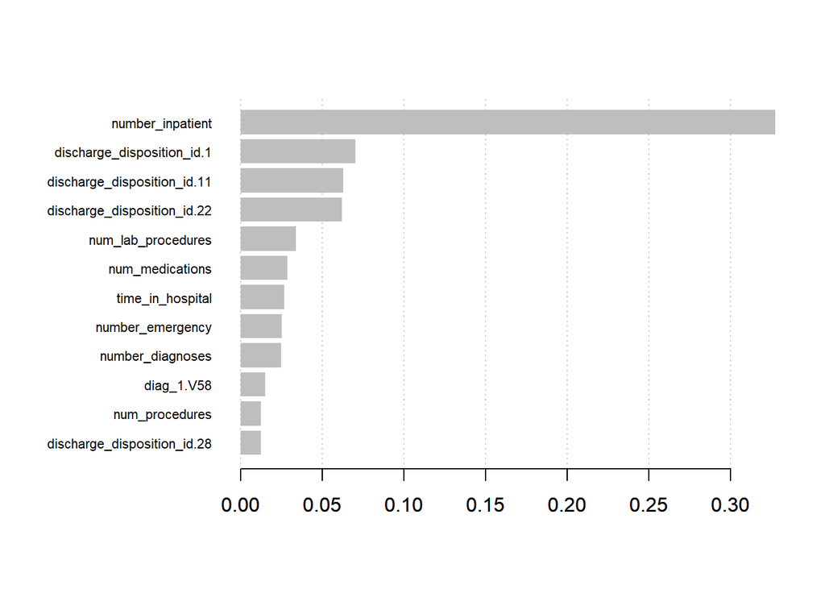

-Por otro lado, con mayor disponibilidad de tiempo para el análisis se sugeriría hacer tratamiento de outliers, reducción de dimensionalidad y data binning.

-También se sugeriría correr otras modelos de clasificación más simples como una regresión logística o ensambles tipo bagging para comparar su desempeño.